# Simulate Admixed Populations with `bnpsd`

Alejandro Ochoa and John D. Storey

2021-08-23

$$\newcommand{\Fst}{F_{\text{ST}}}
\newcommand{\ft}[1][j]{f_{#1}^T}$$

# Introduction

The `bnpsd` package simulates the genotypes of an admixed population. In the Pritchard-Stephens-Donnelly (PSD) model (Pritchard, Stephens, and Donnelly 2000), admixed individuals draw their alleles with individual-specific probabilities (admixture proportions) from $K$ intermediate subpopulations. We impose the Balding-Nichols (BN) model (Balding and Nichols 1995) to the intermediate subpopulation allele frequency, which thus evolve independently with subpopulation-specific inbreeding coefficients ($\Fst$ values) from a common ancestral population $T$. The kinship coefficients and generalized $\Fst$ of the admixed individuals were derived in recent work (Ochoa and Storey 2016). A simulated admixed population generated using this package was used to benchmark kinship and $\Fst$ estimators in the accompanying paper (Ochoa and Storey 2021). Here we briefly summarize the notation and intuition behind the key parameters (see (Ochoa and Storey 2016) for precise definitions).

There are conceptually two parts of the BN-PSD model, one that defines relatedness between individuals (under the admixture framework), while the other simulates allele frequencies and genotypes conditional on the specified parameters of relatedness/admixture.

## The BN-PSD population structure

The population structure determines how individuals are related to each other. The key parameters are the coancestry coefficients of the intermediate subpopulations and the admixture proportions of each individual for each subpopulation ($q_{ju}$), which are treated as fixed variables.

The `bnpsd` functions that model population structure (not drawing allele frequencies or genotypes) admit arbitrary coancestry matrices for the intermediate subpopulations. However, the code that draws allele frequencies and genotypes requires these subpopulations to be *independent*, which means that the coancestry matrix must have zero values off-diagonal. In this setting—the only case we’ll considered in this vignette—the diagonal values of the coancestry matrix of the intermediate subpopulations are inbreeding coefficients ($\ft[S_u]$ below), which correspond to subpopulation-specific $\Fst$ values.

Each intermediate subpopulation $S_u$ ($u \in \{1, ..., K\}$) evolved independently from a shared ancestral population $T$ with an inbreeding coefficient denoted by $\ft[S_u]$. Note that $T$ is a superscript, and does not stand for exponentiation or matrix transposition. Each admixed individual $j \in \{1, ..., n\}$ draws each allele from $S_u$ with probability given by the admixture proportion $q_{ju}$ ($\sum_{u=1}^K q_{ju} = 1 \forall j$). In this case the coancestry coefficients $\theta^T_{jk}$ between individuals $j,k$ (including $j=k$ case) and the $\Fst$ of the admixed individuals are given by:
$$\theta^T_{jk} = \sum_{u=1}^K q_{ju} q_{ku} \ft[S_u],
\quad \quad
\Fst = \sum_{j=1}^n \sum_{u=1}^K w_j q_{ju}^2 \ft[S_u],$$
where $0 < w_j < 1, \sum_{j=1}^n w_j = 1$ are user-defined weights for individuals (default $w_j=\frac{1}{n} \forall j$). Note $\theta^T_{jk}$ equals the kinship coefficient for $j \ne k$ and the inbreeding coefficient for $j=k$.

The bias coefficient $s$ is defined by
$$s = \frac{\bar{\theta}^T}{\Fst}$$
where $\bar{\theta}^T = \sum_{j=1}^n \sum_{k=1}^n w_j w_k \theta_{jk}^T$. This $0 < s \le 1$ approximates the proportional bias of $\Fst$ estimators that assume independent subpopulations, and one `bnpsd` function below fits its parameters to yield a desired $s$.

## Random allele frequencies and genotypes

This section details the distributions of the allele frequencies and genotypes of the various populations or individuals of the BN-PSD model.

Every biallelic locus $i$ in the ancestral population $T$ has an ancestral reference allele frequency denoted by $p_i^T$. By default the `bnpsd` code draws
$$p_i^T \sim \text{Uniform}(a, b)$$
with $a=0.01, b=0.5$, but the code accepts $p_i^T$ from arbitrary distributions (see below).

The distribution of the allele frequency at locus $i$ in subpopulation $S_u$, denoted by $p_i^{S_u}$, is the BN distribution:
$$p_i^{S_u} | T \sim \text{Beta} \left( \nu_s p_i^T, \nu_s \left( 1-p_i^T \right) \right),$$
where $\nu_s = \frac{1}{\ft[S_u]}-1$. Allele frequencies for different loci and different subpopulations ($S_u,S_v, u \ne v$) are drawn independently.

Each admixed individual $j$ at each locus $i$ draws alleles from a mixture of Bernoulli distributions from each intermediate subpopulation, which is mathematically equivalent to assigning what we call individual-specific allele frequencies $\pi_{ij}$ constructed as:
$$\pi_{ij} = \sum_{u=1}^K p_i^{S_u} q_{ju}.$$
The unphased genotype $x_{ij}$ (encoded to count the number of reference alleles) is drawn as:
$$x_{ij}|\pi_{ij} \sim \text{Binomial}(2, \pi_{ij}).$$

# Simulation examples

## Population structure: 1D geography

Let’s generate the same population structure used in the simulation of (Ochoa and Storey 2021).

```r
# this package
library(bnpsd)
# for nice colors
library(RColorBrewer)
# for visualizing coancestry matrix with plot_popkin, and other handy functions
library(popkin)

# dimensions of data/model
# number of individuals (NOTE this is 10x less than in publication!)
n_ind <- 100
# number of intermediate subpops
k_subpops <- 10

# define population structure
# subpopulation FST vector, up to a scalar
inbr_subpops <- 1 : k_subpops
# desired bias coefficient
bias_coeff <- 0.5
# desired FST for the admixed individuals
Fst <- 0.1
# admixture proportions from 1D geography
obj <- admix_prop_1d_linear(
    n_ind = n_ind,
    k_subpops = k_subpops,
    bias_coeff = bias_coeff,
    coanc_subpops = inbr_subpops,
    fst = Fst
)
admix_proportions <- obj$admix_proportions
# rescaled inbreeding vector for intermediate subpopulations
inbr_subpops <- obj$coanc_subpops

# get pop structure parameters of the admixed individuals
coancestry <- coanc_admix(admix_proportions, inbr_subpops)

# verify that we got the desired FST!
fst_admix(admix_proportions, inbr_subpops)
```

```
#> [1] 0.1
```

```r
# the mean of the diagonal of the coancestry matrix also equals FST
inbr <- diag(coancestry)
fst(inbr) # `fst` is a function in the popkin package
```

```
#> [1] 0.1
```

```r
# verify that we got the desired `bias_coeff` too!
mean(coancestry) / Fst
```

```
#> [1] 0.5
```

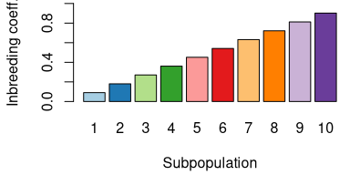

```r
# visualize the per-subpopulation inbreeding coefficients (FSTs)
# shrink default margins
par(mar = c(4, 4, 0, 0) + 0.2)
# colors for independent subpopulations
col_subpops <- brewer.pal(k_subpops, "Paired")

barplot(inbr_subpops, col = col_subpops, names.arg = 1 : k_subpops, ylim = c(0, 1),
    xlab = 'Subpopulation', ylab = 'Inbreeding coeff.')
```

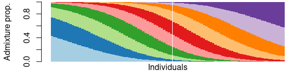

```r
# visualize the admixture proportions
# shrink default margins
par(mar = c(1, 4, 0, 0) + 0.2)
barplot(
    t(admix_proportions),
    col = col_subpops,
    border = NA,
    space = 0,
    ylab = 'Admixture prop.'
)
mtext('Individuals', 1)
```

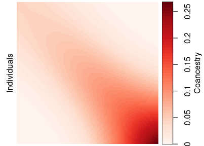

```r
# Visualize the coancestry matrix using "popkin"!
plot_popkin(
    coancestry,
    # zero inner margin (plus padding) because we have no labels
    mar = 0,
    leg_title = 'Coancestry'
)
```